# Data Preprocessing

Miguel Albertí Pons &Iker González Cuellar

07-11-22

```r
library(dplyr)

library(magrittr)

setwd('D:/iCloud/iCloudDrive/Master Big Data/Data Analytics - Teoria_Practica/_r_exercises/3-DataPreprocessing')

BcnPisos = read.delim("_repository/bcn_pisos.txt")
```

#### **1. Let’s play a bit with pipes. Using the pipeline operator perform the following operations:**

##### **a) Compute the squared root of the squared of any number.**

```r
x = 32 %>% .^2 %>% sqrt
print(x)
```

```
## [1] 32
```

```r
standard_sample_function = function(sample){
  (sample - mean(sample))/sd(sample)
  }
rnorm(n=10000,mean=5,sd=3) %>% standard_sample_function() %>% max()
```

```
## [1] 3.691189
```

##### **c) Same as b) but plotting**

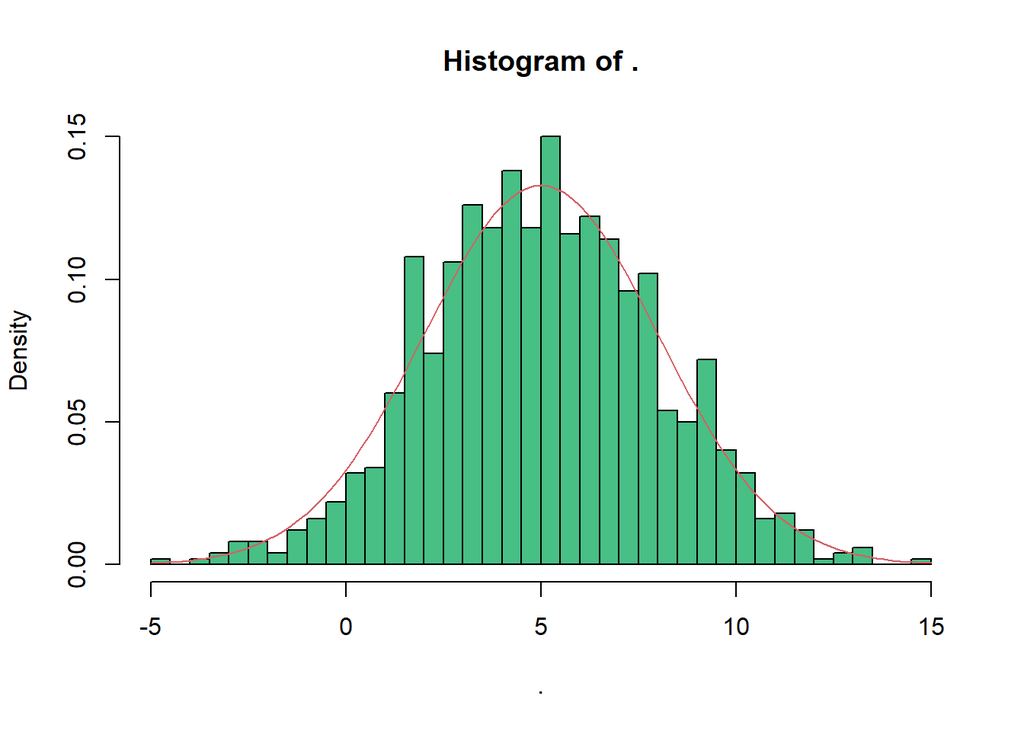

```r
x = rnorm(n= 1000, mean = 5, sd = 3) %T>% hist(., probability = T, breaks = 50, col = '#48BF84')

curve(dnorm(x,5,3), col = '#D65F65', add = T)
```

#### **2. With the pisos dataset and using an only pipeline, compute the following transformations:**

##### **a) Drop the duplicated individuals and compute the mean value of the fats (“Valor”) by district (“Dist”).**

```r
BcnPisosMeanbyDist = BcnPisos %>% unique() %>% group_by(Dist) %>%
  summarise(valor_medio = mean(Valor), pisos_count_dist = n())

print(BcnPisosMeanbyDist)
```

```
## # A tibble: 10 × 3
##    Dist         valor_medio pisos_count_dist
##    <chr>              <dbl>            <int>
##  1 Ciutat_Vella   11523408.              188
##  2 Eixample       21861301.              367
##  3 Gracia         17401416               162
##  4 Horta          15769832.              249
##  5 Les_Corts      28754475.               83
##  6 Nou_Barris     13352474.              223
##  7 Sant_Andreu    15365746.              185
##  8 Sant_Marti     15117212.              325
##  9 Sants          15598655.              319
## 10 Sarria         33022471.              153
```

##### **b) Drop the duplicated individuals, get the numeric features of the dataset and standardize it.**

```r
stdzBcnPisos = BcnPisos %>% unique() %>% select_if(., is.numeric) %>%
  mutate_all(~(scale(.) %>% as.vector))

head(stdzBcnPisos,30)
```

```
##          Valor     Superf       Dorm      Banys       Edat     ValSol
## 1  -1.30602140 -1.6157433 -0.9749402 -0.5875153  1.0361357 -0.4258923
## 2  -1.09834831 -1.2884824 -2.0628190 -0.5875153  2.0970125 -1.0909849
## 3  -0.96773131 -1.2736490 -0.9749402 -0.5875153  1.3897613 -0.1672452
## 4  -0.76761896 -0.7013287  0.1129386 -0.5875153  2.0970125 -0.6475898
## 5   0.18167390  0.3802701 -0.9749402  1.2517340 -1.4392438 -1.1648841
## 6  -0.83611109 -0.2285155 -0.9749402 -0.5875153  2.5567259 -1.5343800
## 7  -1.13816908 -0.7785858 -0.9749402 -0.5875153  1.7433869 -1.5343800
## 8  -0.79288259 -0.6549745 -0.9749402 -0.5875153 -0.5551797 -0.8877622
## 9  -1.19892544 -1.1648711 -0.9749402 -0.5875153  1.3897613 -1.1648841
## 10 -0.80113401 -0.2285155 -0.9749402 -0.5875153  2.5567259 -1.5343800
## 11  0.03408381  0.1447906 -0.9749402  1.2517340 -0.7673551 -0.7953882
## 12 -1.15048509 -1.1030655 -0.9749402 -0.5875153  3.7944156 -1.1648841
## 13 -1.19577625 -1.3811909 -2.0628190 -0.5875153  1.7433869 -1.3496320
## 14 -0.85807903 -1.3811909 -2.0628190 -0.5875153 -0.5551797 -0.4258923
```

[output cut: 16 more lines]

##### **c) Drop the duplicated individuals, add a new factor to the dataset “Greater than is mean”with values (Y,N) indicating if the Value (“Valor”) of the at is greater or not than the mean of the flats in the district.**

```r
BcnPisosUniqueMeans = BcnPisos %>% unique(.) %>% left_join(., BcnPisosMeanbyDist, by = 'Dist') %>% mutate("Greater than is mean" = if_else(Valor > valor_medio, "Yes", "No"))

head(BcnPisosUniqueMeans,50)
```

```
##       Valor Superf Dorm Banys Edat Estat Planta         Dist    ValSol Tipus
## 1   4962780  31.41    2     1   70  1_MM Planta Ciutat_Vella 113322.15  MANZ
## 2   7001400  42.00    1     1  100   2_M Planta Ciutat_Vella  89407.53  MANZ
## 3   8283600  42.48    2     1   80   2_M Planta Ciutat_Vella 122622.28  MANZ
## 4  10248000  61.00    3     1  100  1_MM Planta Ciutat_Vella 105350.61  MANZ
## 5  19566720  96.00    2     2    0  5_MB Planta Ciutat_Vella  86750.35  MANZ
## 6   9575648  76.30    2     1  113  1_MM   Atic Ciutat_Vella  73464.45  MANZ
## 7   6610500  58.50    2     1   90  1_MM Planta Ciutat_Vella  73464.45  MANZ
## 8  10000000  62.50    2     1   25  1_MM Planta Ciutat_Vella  96714.77  MANZ
## 9   6014086  46.00    2     1   80  1_MM Planta Ciutat_Vella  86750.35  MANZ
## 10  9919000  76.30    2     1  113  1_MM   Atic Ciutat_Vella  73464.45  MANZ
## 11 18117904  88.38    2     2   19   3_N   Atic Ciutat_Vella 100036.25  MANZ
## 12  6489600  48.00    2     1  148  1_MM Planta Ciutat_Vella  86750.35  MANZ
## 13  6045000  39.00    1     1   90   3_N Planta Ciutat_Vella  80107.40  MANZ
## 14  9360000  39.00    1     1   25   4_B Planta Ciutat_Vella 113322.15  MANZ
```

[output cut: 87 more lines]

#### **3. Finally, you are asked to do a complete transformation of the pisos dataset.**

#### **We want to analyse and visualize some general features of the districts of the city, characterizing a sample of flats.**

##### **a) Propose R code for the transformation of this dataset. You are free to use any technique explained during the course (and others) but the use of some pipes will be valued positively (7 points).**

Para este apartado hemos propuesto dos códigos diferentes de R:

**Propuesta 1**: Aborda el problema a través de transformaciones de la tabla Bcn Pisos: normaliza y categoriza las variables de acuerdo al listado solicitado, divide la tabla normalizada en dos partes para sus respectivos cálculos (mean y count) y por último, crea el resumen de variables utilizando la función pivot y join.

**Propuesta 2:** Aborda el problema de forma directa y eficiente a través de una función utilizando los comandos de goup_by y summirise.

Desde nuestro punto de vista, la propuesta 1 permite una mayor flexibilidad en cuanto a la transformación, cálculo y visualización de las variables, sin embargo, esta opción es menos eficiente en tiempos de ejecución por las transformaciones y joins que se realiza en el proceso.

La propuesta 2, es más eficiente en tiempos de ejecución (de acuerdo a los tiempos del sistema) ya que utiliza funciones específicas para la creación de la tabla solicitada sin realizar diversas transformaciones ni joins los cuales penalizan el rendimiento.

*# Código Propuesta 1:*

```r
library(reshape2)
library(tidyr)
start_time <- Sys.time()

# CODIFICACIÓN BIG IF PARA ETIQUETAR LAS VARIABLES EN SUB_VARIABLES DE ACUERDO AL LISTADO SOLICITADO

bigIf = function (x) {
  if_else(x$variable == "Valor", "Valor",
          if_else(x$variable == "Superf", "Superf",
                  if_else((x$variable == "Dorm" & x$value == 1), "1 Dorm",
                          if_else((x$variable == "Dorm" & x$value == 2), "2 Dorm",
                                  if_else((x$variable == "Dorm" & x$value == 3), "3 Dorm",
                                          if_else((x$variable == "Dorm" & x$value == 4), "4 Dorm",
                                                  if_else((x$variable == "Dorm" & x$value == 5), "5 Dorm",
                                                          if_else((x$variable == "Ascens" & x$value == "SI"), "AscS",
                                                                  if_else((x$variable == "Ascens" & x$value == "NO"), "AscN",
                                                                          if_else((x$variable == "Planta" & x$value == "Atic"), "Atics",
                                                                                  if_else((x$variable == "Planta" & x$value == "Planta"), "Plantas",
                                                                                          if_else((x$variable == "Planta" & x$value == "Bajos"), "Bajos",
                                                                                                  if_else((x$variable == "Edat" & as.integer(x$value) <= 10), "Nous",
                                                                                                          if_else((x$variable == "Edat" & as.integer(x$value) >= 11 & as.integer(x$value) <= 20), "SemiNous",
                                                                                                                  if_else((x$variable == "Edat" & as.integer(x$value) >= 21 & as.integer(x$value) <= 50), "Vells",
                                                                                                                          if_else((x$variable == "Edat" & as.integer(x$value) >= 51), "MoltVells",
                                                                                                                                  "0 Unused Variables"
                                                                          ))))))))))))))))

}

# TRANSFORMACIÓN PASO 1:

BcnPisosTransform = BcnPisos[,c(1:3,5,7:8,11)] %>% unique(.) %>% melt(., id.vars = "Dist") %>% mutate("sub_variable" = suppressWarnings(bigIf(.)))             # se ignoran los warning arrojados por la función del BIG IF, puesto que se ha validado previamente la tabla y no se ha introducido ningún NA en el data frame trás su aplicación.

# TRANSFORMACIÓN PASO 2:

BcnPisosToMean = BcnPisosTransform[BcnPisosTransform$sub_variable == c("Valor","Superf"),] %>% .[,c(1,3,4)] %>% transform(., value = as.numeric(value)) %>% pivot_wider(names_from = sub_variable, values_from = value, values_fn = mean)


BcnPisosToCount = BcnPisosTransform[!(BcnPisosTransform$sub_variable %in% c("Valor","Superf")),] %>% .[,c(1,4)] %>% mutate("countObs" = 1) %>% pivot_wider(names_from = sub_variable, values_from = countObs, values_fn = sum, values_fill = 0, names_sort = T)

# TRANSFORMACIÓN PASO 3:

P1_BcnPisoSummary = full_join(BcnPisosToMean, BcnPisosToCount, by = "Dist")


print(P1_BcnPisoSummary)
```

```
## # A tibble: 10 × 17
##    Dist   Valor Superf 1 Dor…¹ 2 Dor…² 3 Dor…³ 4 Dor…⁴ 5 Dor…⁵  AscN  AscS Atics
##    <chr>  <dbl>  <dbl>   <dbl>   <dbl>   <dbl>   <dbl>   <dbl> <dbl> <dbl> <dbl>
##  1 Ciut… 1.15e7   67.5      51      67      53      13       3   151    36    23
##  2 Sant… 1.54e7   80.7      16      70     187      51       1   116   209    20
##  3 Sants 1.55e7   78.1      23      70     164      59       1    95   222    33
##  4 Eixa… 2.18e7   94.7      24      63     126     125      29    84   283    33
##  5 Sarr… 3.22e7  112.       15      21      45      50      22    22   131    16
##  6 Grac… 1.72e7   82.9      13      41      68      34       6    81    81    12
##  7 Horta 1.67e7   81.6      12      52     139      45       1   138   111    42
##  8 Les_… 2.78e7  102.        1      13      33      31       5    15    68     8
##  9 Nou_… 1.32e7   73.4       6      65     127      25       0   117   106    42
## 10 Sant… 1.47e7   77.3      11      32     106      35       1    64   121    18
## # … with 6 more variables: Bajos <dbl>, MoltVells <dbl>, Nous <dbl>,
## #   Plantas <dbl>, SemiNous <dbl>, Vells <dbl>, and abbreviated variable names
## #   ¹`1 Dorm`, ²`2 Dorm`, ³`3 Dorm`, ⁴`4 Dorm`, ⁵`5 Dorm`
```

```r
end_time <- Sys.time()

cat("P1 -> Code chunk running time of :", end_time - start_time)
```

```
## P1 -> Code chunk running time of : 0.312763
```

*# Código Propuesta 2:*

```r
start_time <- Sys.time()

get_new_data_frame = function(sample){
  new_data__frame = sample %>% group_by(Dist) %>%
    summarise(mean_valor = mean(Valor),
              un_dorm = sum(Dorm == 1),
              dos_dorm = sum(Dorm == 2),
              tres_dorm = sum(Dorm == 3),
              cuatro_dorm = sum(Dorm == 4),
              cinco_dorm = sum(Dorm == 5),
              with_ascens = sum(Ascens == "SI"),
              without_ascens = sum(Ascens == "NO"),
              num_atic = sum(Planta == "Atic"),
              num_planta = sum(Planta == "Planta"),
              num_bajos = sum(Planta == "Bajos"),
              num_nous = sum(Edat <= 10),
              num_semi_nous = sum(Edat >= 11 & Edat <= 20),
              num_vells = sum(Edat >= 21 & Edat <= 50),
              num_molt_vells = sum(Edat >= 51),
              mean_superf = mean(Superf),
              )
  return(new_data__frame)
}

P2_BcnPisoSummary = BcnPisos %>% unique(.) %>% get_new_data_frame

print(P2_BcnPisoSummary)
```

```
## # A tibble: 10 × 17
##    Dist  mean_…¹ un_dorm dos_d…² tres_…³ cuatr…⁴ cinco…⁵ with_…⁶ witho…⁷ num_a…⁸
##    <chr>   <dbl>   <int>   <int>   <int>   <int>   <int>   <int>   <int>   <int>
##  1 Ciut…  1.15e7      51      68      53      13       3      37     151      23
##  2 Eixa…  2.19e7      24      63     126     125      29     283      84      33
##  3 Grac…  1.74e7      13      41      68      34       6      81      81      12
##  4 Horta  1.58e7      12      52     139      45       1     111     138      42
##  5 Les_…  2.88e7       1      13      33      31       5      68      15       8
##  6 Nou_…  1.34e7       6      65     127      25       0     106     117      42
##  7 Sant…  1.54e7      11      32     106      35       1     121      64      18
##  8 Sant…  1.51e7      16      70     187      51       1     209     116      20
##  9 Sants  1.56e7      23      71     165      59       1     223      96      33
## 10 Sarr…  3.30e7      15      21      45      50      22     131      22      16
## # … with 7 more variables: num_planta <int>, num_bajos <int>, num_nous <int>,
## #   num_semi_nous <int>, num_vells <int>, num_molt_vells <int>,
## #   mean_superf <dbl>, and abbreviated variable names ¹mean_valor, ²dos_dorm,
## #   ³tres_dorm, ⁴cuatro_dorm, ⁵cinco_dorm, ⁶with_ascens, ⁷without_ascens,
## #   ⁸num_atic
```

```r
end_time <- Sys.time()

cat("P2 -> Code chunk running time of :", end_time - start_time)
```

```
## P2 -> Code chunk running time of : 0.2122762
```

##### **b) Propose nice visualizations of this new dataset (3 points)**

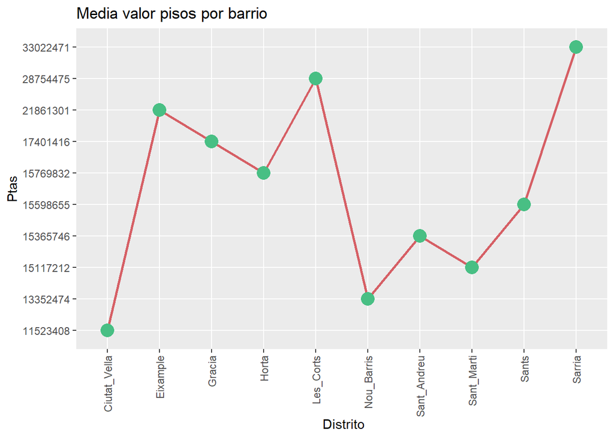

```r
library(ggplot2)

colorPalett = c("#99E47E", "#48BF84", "#439775", "#3C7A80", "#D65F65")

# Line Chart: Valor Medio Pisos

ValorChart = ggplot(P2_BcnPisoSummary, aes(y = format(as.numeric(mean_valor),scientific=F), x = Dist, group = 1)) + geom_line(color = "#D65F65", linewidth = 1) + geom_point(color = "#48BF84", size = 5) + theme(axis.text.x = element_text(angle = 90, vjust = 0.5, hjust=1)) + ggtitle("Media valor pisos por barrio") + labs(y = "Ptas", x = " Distrito") + scale_fill_manual(values=colorPalett)

print(ValorChart)
```

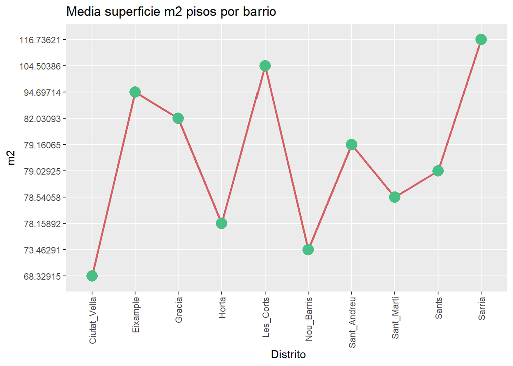

```r
# Line Chart: Superficie m2 Media Pisos

SuperfChart = ggplot(P2_BcnPisoSummary, aes(y = format(as.numeric(mean_superf),scientific=F), x = Dist, group = 1)) + geom_line(color = "#D65F65", linewidth = 1) + geom_point(color = "#48BF84", size = 5) + theme(axis.text.x = element_text(angle = 90, vjust = 0.5, hjust=1)) + ggtitle("Media superficie m2 pisos por barrio") + labs(y = "m2", x = " Distrito") + scale_fill_manual(values=colorPalett)

print(SuperfChart)
```

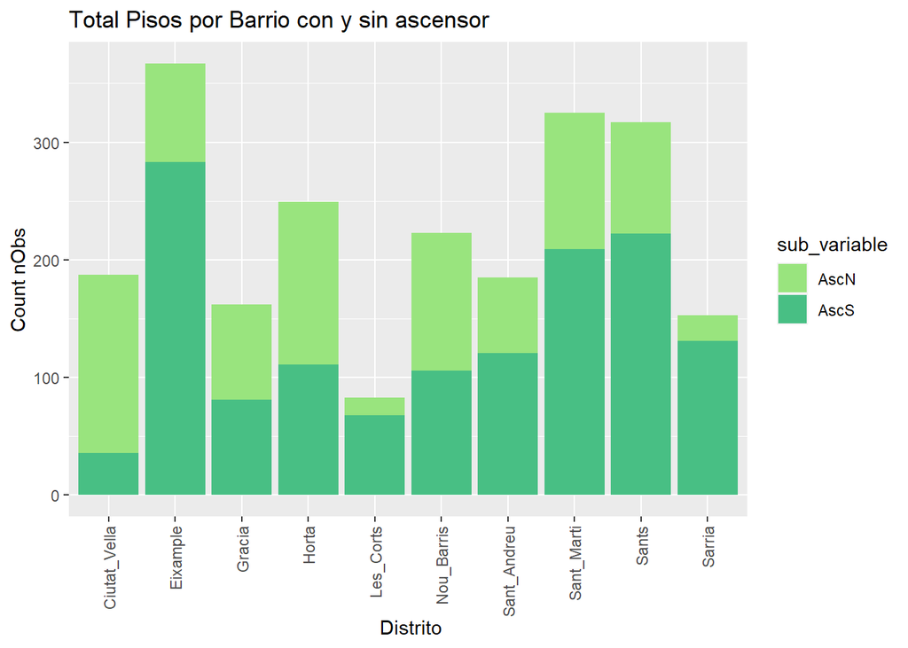

```r
# Stacked Bar Chart: Ascensor si/no

AsencChart = BcnPisosTransform[BcnPisosTransform$variable == "Ascens",] %>% mutate("nObs" = 1) %>% ggplot(., aes(fill = sub_variable , y = nObs, x = Dist)) +
  geom_bar(position = "stack", stat='identity') + theme(axis.text.x = element_text(angle = 90, vjust = 0.5, hjust=1)) + ggtitle("Total Pisos por Barrio con y sin ascensor") + labs(y = "Count nObs", x = " Distrito") + scale_fill_manual(values=colorPalett)

print(AsencChart)
```

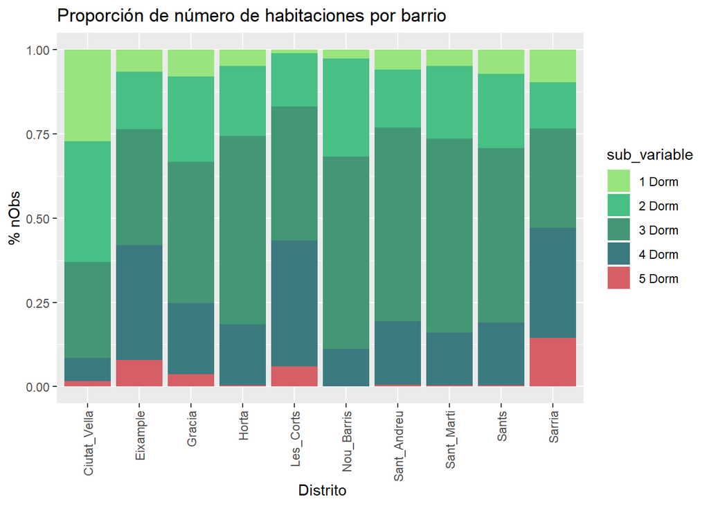

```r
# Stacked Bar Chart: Número de Dormitorios

DormChart = BcnPisosTransform[BcnPisosTransform$variable == "Dorm",] %>% mutate("nObs" = 1) %>% ggplot(., aes(fill = sub_variable , y = nObs, x = Dist)) +
  geom_bar(position = "fill", stat='identity') + theme(axis.text.x = element_text(angle = 90, vjust = 0.5, hjust=1)) + ggtitle("Proporción de número de habitaciones por barrio") + labs(y = "% nObs", x = " Distrito") + scale_fill_manual(values=colorPalett)

print(DormChart)
```

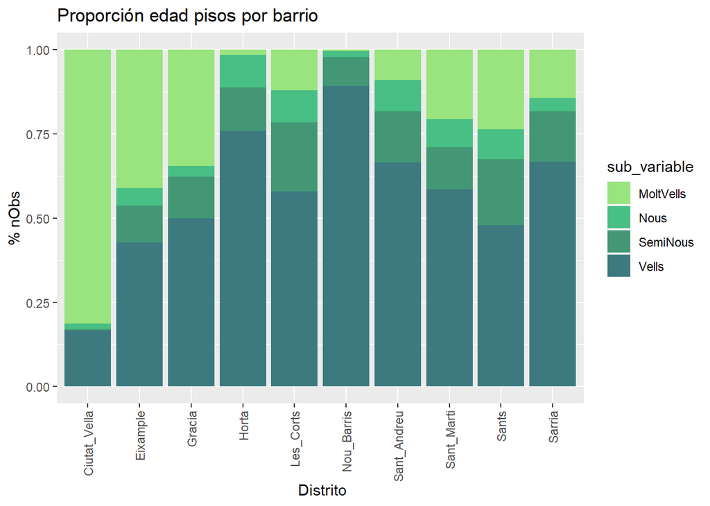

```r
# Stacked Bar Chart: Edades Pisos

EdadChart = BcnPisosTransform[BcnPisosTransform$variable == "Edat",] %>% mutate("nObs" = 1) %>% ggplot(., aes(fill = sub_variable , y = nObs, x = Dist)) +
  geom_bar(position = "fill", stat='identity') + theme(axis.text.x = element_text(angle = 90, vjust = 0.5, hjust=1)) + ggtitle("Proporción edad pisos por barrio") + labs(y = "% nObs", x = " Distrito") + scale_fill_manual(values=colorPalett)

print(EdadChart)
```

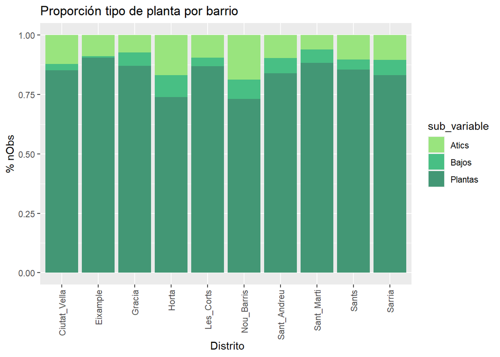

```r
# Stacked Bar Chart: Planta Pisos

PlantaChart = BcnPisosTransform[BcnPisosTransform$variable == "Planta",] %>% mutate("nObs" = 1) %>% ggplot(., aes(fill = sub_variable , y = nObs, x = Dist)) +
  geom_bar(position = "fill", stat='identity') + theme(axis.text.x = element_text(angle = 90, vjust = 0.5, hjust=1)) + ggtitle("Proporción tipo de planta por barrio") + labs(y = "% nObs", x = " Distrito") + scale_fill_manual(values=colorPalett)

print(PlantaChart)
```